# Inplate_tag_mapping

Ravin Poudel

05 January, 2021

```r
# load library and data
library(tidyverse)
library(knitr)
library(kableExtra)


# load inplate mapping data
tag_plate <- read.csv("Plate_mapping_october2020/PlateMappingReads.csv", header = TRUE, stringsAsFactors = FALSE)

# Correct one of the tag , as it was written in small letter
tag_plate$up_constant <- gsub("BSup2","BSUp2", tag_plate$up_constant)
```

The goal here is to find the best 20-bp-random-barcode (rb20) associated with each pair of ups and downs in-plate tag. There are cases, where the same rb20 is associated with multiple pairs of inline tags. In such cases, we are likely to associated the same rb20 with multiple inline barcode. So, rather than searching the best rb20 by in-line tag, what we can do is: first find the all the pairs of tags associated with a rb20, then count which pairs has the highest number of reads (best-pairs). In doing so, once the rb20 is assigned to the best-pairs, then the same rb20 cannot be assigned to any other tag pairs.

```r
# group by tags and rb20, and select one with read count > 5000, so that we can plot it as image.
cutseqcount <- tag_plate %>%
  group_by(cutseq,up_constant,down_constant) %>%
  tally() %>%
  arrange(desc(n)) %>%
  mutate(ups_downs = paste0(up_constant,"_",down_constant)) %>%
  filter(n > 5000)
```

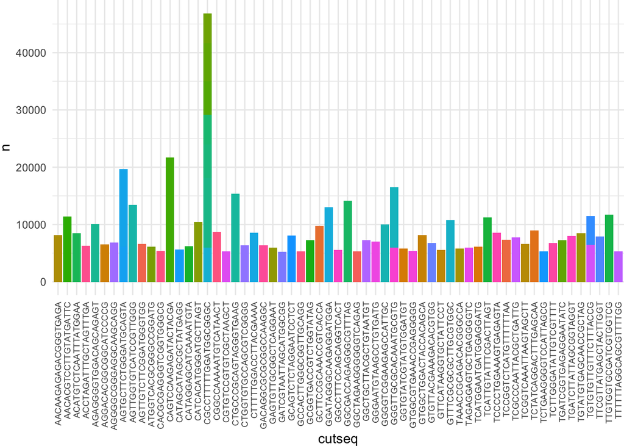

```r
# Stacked barplot with multiple groups
ggplot(data=cutseqcount, aes(x=cutseq, y=n, fill=ups_downs)) +
  geom_bar(position="stack", stat="identity")+
  theme_minimal()+
  theme(legend.position="none")+
  theme(axis.text.x = element_text(angle = 90, vjust = 0.5, hjust=1, size = 7))+
  theme(plot.margin=unit(c(0,0,0,0),"cm"))
```

*Note:* Some of the tag is associated with multiple in-line tags, at quite high number of reads.

Let look at the distrubutuon of reads for a tag across all the matching pairs of in-line barcode.

```r
cutseqonly <- tag_plate %>%
  group_by(cutseq) %>%
  tally() %>%
  arrange(desc(n)) %>%
  mutate(percentage = n/sum(n)*100)

head(cutseqonly)
```

```
## # A tibble: 6 x 3
##   cutseq                    n percentage
##   <chr>                 <int>      <dbl>
## 1 CGCCTTTTTGGATGGCGGGC 178530       9.60
## 2 ACCACGACACGATCGGGAGG  91719       4.93
## 3 TTAATAGAATTAGCGTAAGG  52245       2.81
## 4 TTTCTGTTTAAGTTAGCAGT  40290       2.17
## 5 CAGTCCAAGAGATACTACGA  26919       1.45
## 6 AGTGCTTCTGGGATGCAGTA  23717       1.28
```

Select tag with highest read count i.e. `CGCCTTTTTGGATGGCGGGC` with read counts of `178530`. This accounts for ~ 10% of the total reads.

```r
higest_tag <- tag_plate %>%
  filter (cutseq =="CGCCTTTTTGGATGGCGGGC") %>%
  group_by(cutseq,up_constant,down_constant) %>%
  tally() %>%
  arrange(desc(n)) %>%
  mutate(per_on_onetagPair = n/178530 *100) %>%
   mutate(per_on_entireLibrary = n/ 1860004 *100) %>%
  mutate(ups_downs = paste0(up_constant,"_",down_constant)) %>%
  filter(n > 500)

head(higest_tag)
```

```
## # A tibble: 6 x 7
## # Groups:   cutseq, up_constant [3]
##   cutseq up_constant down_constant     n per_on_onetagPa… per_on_entireLi…
##   <chr>  <chr>       <chr>         <int>            <dbl>            <dbl>
## 1 CGCCT… BSUp3       BSDn19_rc     12205             6.84            0.656
## 2 CGCCT… BSUp2       BSDn19_rc      6598             3.70            0.355
## 3 CGCCT… BSUp4       BSDn20_rc      5938             3.33            0.319
## 4 CGCCT… BSUp2       BSDn20_rc      5864             3.28            0.315
## 5 CGCCT… BSUp3       BSDn18_rc      5820             3.26            0.313
## 6 CGCCT… BSUp2       BSDn18_rc      5214             2.92            0.280
## # … with 1 more variable: ups_downs <chr>
```

`BSUp3_BSDn19_rc` pair has the highest number of read counts for rb20: `CGCCTTTTTGGATGGCGGGC`, which is about **~7%** of the reads observed for `CGCCTTTTTGGATGGCGGGC` or **0.656 %** of the entire library.

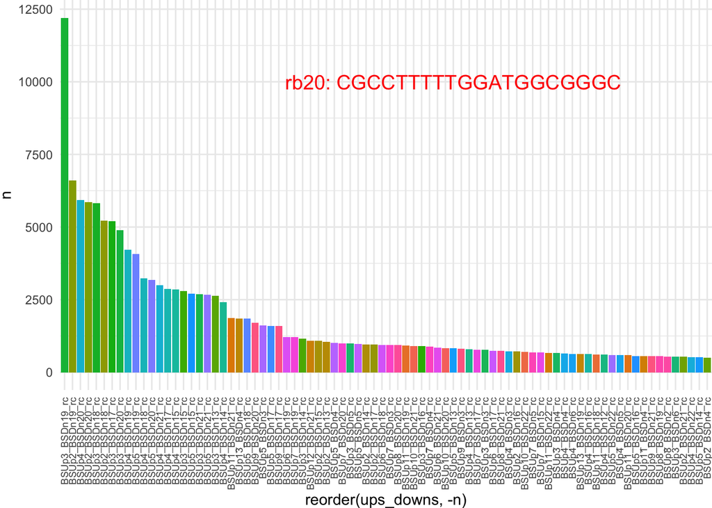

```r
# Stacked barplot with multiple groups
ggplot(data=higest_tag, aes(x=reorder(ups_downs, -n), y=n, fill=ups_downs)) +
  geom_bar(position="dodge", stat="identity") +
  theme_minimal()+
  theme(legend.position="none")+
  theme(axis.text.x = element_text(angle = 90, vjust = 0.5, hjust=1, size = 7))+
  theme(plot.margin=unit(c(0,0,0,0),"cm"))+
  annotate(geom="text", x=50, y=10000, label="rb20: CGCCTTTTTGGATGGCGGGC",color="red", size=5)
```

Here, `BSUp3_BSDn19_rc` is the tag pair with the highest read count. Thus, `CGCCTTTTTGGATGGCGGGC` get associated with `BSUp3_BSDn19_rc`. In the case of second highest i.e. `BSUp2_BSDn19_rc`, the read count is 6598. Note,that with this approach of assigning a rb20 to only one tag-pairs, there is possibility of any other rb20 with count less than that of `CGCCTTTTTGGATGGCGGGC` (6598) assigned to `BSUp3_BSDn19_rc`.

Now, let apply the same rule to all the identified 20rb, the assign the best tag-pairs.

```r
# get all unique rb20
cutseq_uniq <- unique(tag_plate$cutseq)

# empty list to save data from loop
best_ups <- list()
best_downs <- list()
best_count <- list()

# # loop via the length of cutseq_uniq, and for each tag-pair find the tag-pairs with highest count.
# for (i in 1:length(cutseq_uniq)){
#   cs <- cutseq_uniq[i]
#   tp <- tag_plate %>%
#     filter(cutseq==cs) %>%
#     group_by(cutseq, up_constant, down_constant) %>%
#     tally() %>%
#     arrange(desc(n))
#   best_row <-  tp[1, ]
#   best_ups [i] <-  best_row$up_constant
#   best_downs [i] <- best_row$down_constant
#   best_count [i] <- best_row$n
# }

# create a dataframe with cutseq, best_ups, best_downs, and associated read counts.
# best_df <- data.frame(cutseq=cutseq_uniq, ups = unlist(best_ups), down = unlist(best_downs), count = unlist(best_count))
# head(best_df)

# this loop takes a long time to run. I saved the output as dataframe so that I don't have to run it again and again.
best_df <- read.csv("best_df.csv", header = TRUE, stringsAsFactors = FALSE)
head(best_df)
```

```
##   X               cutseq   ups      down count
## 1 1 TCTAGCTTGGTATACTAGAA BSUp7  BSDn2_rc  3705
## 2 2 TTTCTGTTTAAGTTAGCAGT BSUp4 BSDn20_rc  2362
## 3 3 ACCACGACACGATCGGGAGG BSUp4 BSDn20_rc  3820
## 4 4 AGACTTGCGGGAGGCGCGTG BSUp8  BSDn8_rc  3853
## 5 5 GCTTCGGGTGGGCGGACATG BSUp3 BSDn13_rc    31
## 6 6 CGCCTTTTTGGATGGCGGGC BSUp3 BSDn19_rc 12205
```

## Mcount normalized to the the total numnber of reads observed per rb20.

```r
library(tidyverse)
cutseq_count <- tag_plate %>%
  group_by(cutseq) %>%
  tally()
```

```r
######### mapping barcode rads
# barcodeMapping <- read.csv("Plate_mapping_october2020/BarcodeGenomeMappingReads.csv", header = TRUE, stringsAsFactors = FALSE)
#
# barcode_cutseq_count <- barcodeMapping %>%
#   group_by(cutseq) %>%
#   tally() %>%
#   arrange(desc(n))

# mapping output from Perl script working from the original paper describing Random Barcode TnSeq method
barcodeMapping <- read.delim("DSS3BlPl.txt")
head(barcodeMapping)
```

```
##                barcode            rcbarcode nTot   n     scaffold strand
## 1 ATTCTTTATGGTTTAGGGTA TACCCTAAACCATAAAGAAT  125 125 NC_003911.12      -
## 2 GCATGATCACTTTCACGATA TATCGTGAAAGTGATCATGC   55  55 NC_003911.12      -
## 3 AGCTATATGTCTAATAAAAA TTTTTATTAGACATATAGCT   41  41 NC_003911.12      -
## 4 GTAGAAGGACTGGAGCTGCG CGCAGCTCCAGTCCTTCTAC   66  66 NC_003911.12      -
## 5 AGGTGTTGTTGCGGGCTTGC GCAAGCCCGCAACAACACCT   46  46  NC_006569.1      +
## 6 CCTAATAAGTTACCTTAACA TGTTAAGGTAACTTATTAGG   78  78 NC_003911.12      +
##       pos n2 scaffold2 strand2 pos2 nPastEnd
## 1 2897260  0                     NA        0
## 2 2217920  0                     NA        0
## 3 1447486  0                     NA        0
## 4 1283511  0                     NA        0
## 5  475131  0                     NA        0
## 6  384870  0                     NA        0
```

```r
barcode_cutseq_count <- barcodeMapping %>%
  group_by(barcode) %>%
  tally() %>%
  arrange(desc(n))
```

We will convert the `best_df` to two matrix: one for count and another for rb20. Rows represents ups-tag and column represents downs-tag.

```r
# create vector to repsents row and column, with ups and downs tag
ups <-paste0("BSUp",1:16)
downs <- paste0("BSDn",1:24,"_rc")

# create an empty matrix and convert to dataframe with row and column name. This one for saving count.
Mcount <- data.frame(matrix(ncol = length(downs), nrow = length(ups)))
colnames(Mcount) <- downs
rownames(Mcount) <- ups

# create an empty matrix and convert to dataframe with row and column name. This one for saving count normalized by total reads in the library i.e. 1860004
Mcount_outof_TotalLibrary <- data.frame(matrix(ncol = length(downs), nrow = length(ups)))
colnames(Mcount_outof_TotalLibrary) <- downs
rownames(Mcount_outof_TotalLibrary) <- ups


# create an empty matrix and convert to dataframe with row and column name. This one for saving count, normalized by the reads observed for each unique barcode
Mcount_outof_cutseqCount <- data.frame(matrix(ncol = length(downs), nrow = length(ups)))
colnames(Mcount_outof_cutseqCount) <- downs
rownames(Mcount_outof_cutseqCount) <- ups

# create an empty matrix and convert to dataframe with row and column name. This one for saving rb20.
Mrb <- data.frame(matrix(ncol = length(downs), nrow = length(ups)))
colnames(Mrb) <- downs
rownames(Mrb) <- ups

# create an empty matrix and convert to dataframe with row and column name. This one for saving count, normalized by the reads observed for each unique barcode
BarCount <- data.frame(matrix(ncol = length(downs), nrow = length(ups)))
colnames(BarCount) <- downs
rownames(BarCount) <- ups


# create an empty matrix and convert to dataframe with row and column name. This one for saving count, normalized by the reads observed for each unique barcode
MBarcode <- data.frame(matrix(ncol = length(downs), nrow = length(ups)))
colnames(MBarcode ) <- downs
rownames(MBarcode ) <- ups


# for each tag-paris find the best cutseq
for (r in 1:length(ups)){
  rc <- ups[r]
  for (col in 1:length(downs)){
    cc <- downs[col]
    getind <- best_df %>% filter(ups==rc & down == cc)
    if (dim(getind)[1]< 1){
      Mcount[r,col] <- NA
      Mrb[r,col] <- NA
    }else{
      max_one <- getind %>% arrange(desc(count))
      max_one_row <-  max_one[1, ]
      Mcount[r,col] <-  max_one_row$count
      getcutseq <- as.character(max_one_row$cutseq)
      Mrb[r,col] <- getcutseq
      Mcount_outof_TotalLibrary[r,col] <- max_one_row$count / 1860004  * 100
      get_count_for_cutseq <- cutseq_count %>% filter(cutseq==getcutseq) %>% pull(n)
      Mcount_outof_cutseqCount[r,col] <- max_one_row$count / get_count_for_cutseq  * 100

      # find matching getcutseq in barcode mapping in barcode_cutseq_count
      aa = barcode_cutseq_count %>%
        filter(barcode == getcutseq)
      if (dim(aa)[1]< 1){
      BarCount[r,col] <- NA
      MBarcode[r,col] <- NA
    }else{
      BarCount[r,col] <- aa$n
      MBarcode[r,col] <- as.character(aa$barcode)
      }
    }
  }
}
```

Let look at Mcount and Mrb.

#### Mcount: Matrix for count

```r
kbl(Mcount) %>%
  kable_paper() %>%
  scroll_box(width = "910px", height = "535px")
```

|  | BSDn1_rc | BSDn2_rc | BSDn3_rc | BSDn4_rc | BSDn5_rc | BSDn6_rc | BSDn7_rc | BSDn8_rc | BSDn9_rc | BSDn10_rc | BSDn11_rc | BSDn12_rc | BSDn13_rc | BSDn14_rc | BSDn15_rc | BSDn16_rc | BSDn17_rc | BSDn18_rc | BSDn19_rc | BSDn20_rc | BSDn21_rc | BSDn22_rc | BSDn23_rc | BSDn24_rc |
| --- | --- | --- | --- | --- | --- | --- | --- | --- | --- | --- | --- | --- | --- | --- | --- | --- | --- | --- | --- | --- | --- | --- | --- | --- |
| BSUp1 | NA | 15 | 1 | 1 | 1 | 1 | 1 | 1 | NA | 1 | 37 | 1 | 1 | 1 | 3 | 1 | 1 | 1 | 1 | 1 | 1 | 1 | NA | NA |
| BSUp2 | 1 | 3 | 21667 | 11403 | 7242 | 6206 | 3023 | 11240 | 1392 | 8441 | 5935 | 1155 | 1608 | 10463 | 4979 | 12 | 6101 | 2594 | 7299 | 13 | 26 | 2 | 2 | 1 |
| BSUp3 | NA | 10122 | 2299 | 15343 | 457 | 3080 | 141 | 2365 | 109 | 11741 | 89 | 8455 | 413 | 14119 | 170 | 3955 | 129 | 3039 | 12205 | 919 | 5 | 174 | 2 | 1 |
| BSUp4 | 1 | 10787 | 12989 | 8535 | 13528 | 537 | 4233 | 4291 | 32 | 13388 | 9985 | 10507 | 4764 | 1740 | 133 | 1194 | 4166 | 4788 | 1310 | 3820 | 4329 | 3859 | 104 | NA |
| BSUp5 | 1 | 22 | 211 | 561 | 187 | 3409 | 50 | 5244 | 156 | 5631 | 1073 | 5331 | 116 | 8049 | 108 | 3710 | 46 | 147 | 41 | 7946 | 23 | 6810 | 869 | 1 |
| BSUp6 | 1 | 3959 | 5999 | 13 | 4727 | 2948 | 2319 | 1397 | 4561 | 6363 | 6849 | 4893 | 7294 | 5308 | 7741 | 6413 | 3518 | 2427 | 5326 | 2 | 2188 | 2 | 1 | NA |
| BSUp7 | NA | 3705 | 45 | 95 | 145 | 1960 | 27 | 5424 | 72 | 3347 | 17 | 4010 | 33 | 7031 | 29 | 2031 | 90 | 1320 | 16 | 1164 | 4 | 151 | 1 | NA |
| BSUp8 | NA | 10 | 1947 | 1842 | 6399 | 2312 | 2567 | 3853 | 2530 | 9 | 5595 | 4024 | 7962 | 8559 | 6775 | 2658 | 2326 | 360 | 4314 | 2271 | 618 | 44 | 2 | NA |
| BSUp9 | NA | 235 | 46 | 2322 | 4242 | 1878 | 6 | 5276 | 24 | 6315 | 39 | 5410 | 23 | 8741 | 38 | 4489 | 40 | 4941 | 1830 | 1228 | 1675 | 1850 | 4143 | 1 |
| BSUp10 | NA | 1 | 572 | 2854 | 2714 | 1076 | 1804 | 4810 | 27 | 2104 | 5299 | 6590 | 7336 | 9757 | 8979 | 4160 | 6106 | 2840 | 5840 | 3764 | 1208 | 292 | 10 | 2 |
| BSUp11 | 4 | 3191 | 753 | 28 | 1048 | 441 | 12 | 5542 | 3156 | 2849 | 3512 | 3845 | 6536 | 3861 | 8194 | 4909 | 3902 | 918 | 1101 | 789 | 1943 | 3237 | 123 | 1 |
| BSUp12 | NA | 377 | 908 | 99 | 694 | 2973 | 1145 | 3240 | 2645 | 525 | 3303 | 858 | 6597 | 4733 | 3040 | 4180 | 34 | 2282 | 1434 | 361 | 1299 | 1318 | 372 | NA |
| BSUp13 | NA | 623 | 258 | 749 | 1838 | 602 | 247 | 458 | 46 | 370 | 3279 | 3068 | 1508 | 2610 | 2114 | 1060 | 966 | 779 | 936 | 1615 | 339 | 286 | 1 | 1 |
| BSUp14 | 57 | 207 | 837 | 1094 | 932 | 533 | 1612 | 2 | 1353 | 1329 | 868 | 3172 | 8116 | 2749 | 5833 | 2037 | 1867 | 752 | 1484 | 981 | 992 | 887 | 2 | NA |
| BSUp15 | NA | 2 | 2 | 1251 | 4 | 1 | 1 | 26 | 730 | 1 | 283 | 1 | 663 | 1832 | 851 | 13 | 694 | 116 | 111 | 55 | 2 | 1 | NA | NA |
| BSUp16 | NA | 1 | 1 | 1 | 2 | 2 | NA | NA | 1 | NA | NA | 1 | 3 | 1 | 1 | 1 | NA | 1 | 1 | 1 | 1 | NA | NA | NA |

#### Mcount_outof_TotalLibrary: Matrix for count normalized by total reads in the library i.e. 1860004

For example: `BSUp3_BSDn19_rc` pair, we have read **count == 12205**, so this when normalize by **library size = 12205/1860004 * 100 == 0.656 %** of the entire library

```r
kbl(Mcount_outof_TotalLibrary) %>%
  kable_paper() %>%
  scroll_box(width = "910px", height = "535px")
```

|  | BSDn1_rc | BSDn2_rc | BSDn3_rc | BSDn4_rc | BSDn5_rc | BSDn6_rc | BSDn7_rc | BSDn8_rc | BSDn9_rc | BSDn10_rc | BSDn11_rc | BSDn12_rc | BSDn13_rc | BSDn14_rc | BSDn15_rc | BSDn16_rc | BSDn17_rc | BSDn18_rc | BSDn19_rc | BSDn20_rc | BSDn21_rc | BSDn22_rc | BSDn23_rc | BSDn24_rc |
| --- | --- | --- | --- | --- | --- | --- | --- | --- | --- | --- | --- | --- | --- | --- | --- | --- | --- | --- | --- | --- | --- | --- | --- | --- |
| BSUp1 | NA | 0.0008064 | 0.0000538 | 0.0000538 | 0.0000538 | 0.0000538 | 0.0000538 | 0.0000538 | NA | 0.0000538 | 0.0019892 | 0.0000538 | 0.0000538 | 0.0000538 | 0.0001613 | 0.0000538 | 0.0000538 | 0.0000538 | 0.0000538 | 0.0000538 | 0.0000538 | 0.0000538 | NA | NA |
| BSUp2 | 0.0000538 | 0.0001613 | 1.1648900 | 0.6130632 | 0.3893540 | 0.3336552 | 0.1625265 | 0.6042998 | 0.0748385 | 0.4538162 | 0.3190853 | 0.0620966 | 0.0864514 | 0.5625257 | 0.2676876 | 0.0006452 | 0.3280100 | 0.1394621 | 0.3924185 | 0.0006989 | 0.0013978 | 0.0001075 | 0.0001075 | 0.0000538 |
| BSUp3 | NA | 0.5441924 | 0.1236019 | 0.8248907 | 0.0245698 | 0.1655910 | 0.0075806 | 0.1271503 | 0.0058602 | 0.6312352 | 0.0047849 | 0.4545689 | 0.0222043 | 0.7590844 | 0.0091398 | 0.2126340 | 0.0069355 | 0.1633867 | 0.6561814 | 0.0494085 | 0.0002688 | 0.0093548 | 0.0001075 | 0.0000538 |
| BSUp4 | 0.0000538 | 0.5799450 | 0.6983318 | 0.4588700 | 0.7273103 | 0.0288709 | 0.2275802 | 0.2306984 | 0.0017204 | 0.7197834 | 0.5368268 | 0.5648913 | 0.2561285 | 0.0935482 | 0.0071505 | 0.0641934 | 0.2239780 | 0.2574188 | 0.0704300 | 0.2053759 | 0.2327414 | 0.2074727 | 0.0055914 | NA |
| BSUp5 | 0.0000538 | 0.0011828 | 0.0113441 | 0.0301612 | 0.0100537 | 0.1832792 | 0.0026882 | 0.2819349 | 0.0083871 | 0.3027413 | 0.0576880 | 0.2866123 | 0.0062365 | 0.4327410 | 0.0058064 | 0.1994619 | 0.0024731 | 0.0079032 | 0.0022043 | 0.4272034 | 0.0012366 | 0.3661282 | 0.0467203 | 0.0000538 |
| BSUp6 | 0.0000538 | 0.2128490 | 0.3225262 | 0.0006989 | 0.2541392 | 0.1584943 | 0.1246772 | 0.0751074 | 0.2452145 | 0.3420960 | 0.3682250 | 0.2630640 | 0.3921497 | 0.2853757 | 0.4161819 | 0.3447842 | 0.1891394 | 0.1304836 | 0.2863435 | 0.0001075 | 0.1176342 | 0.0001075 | 0.0000538 | NA |
| BSUp7 | NA | 0.1991931 | 0.0024193 | 0.0051075 | 0.0077957 | 0.1053761 | 0.0014516 | 0.2916123 | 0.0038710 | 0.1799458 | 0.0009140 | 0.2155909 | 0.0017742 | 0.3780099 | 0.0015591 | 0.1091933 | 0.0048387 | 0.0709676 | 0.0008602 | 0.0625805 | 0.0002151 | 0.0081183 | 0.0000538 | NA |
| BSUp8 | NA | 0.0005376 | 0.1046772 | 0.0990320 | 0.3440315 | 0.1243008 | 0.1380105 | 0.2071501 | 0.1360212 | 0.0004839 | 0.3008058 | 0.2163436 | 0.4280636 | 0.4601603 | 0.3642465 | 0.1429029 | 0.1250535 | 0.0193548 | 0.2319350 | 0.1220965 | 0.0332257 | 0.0023656 | 0.0001075 | NA |
| BSUp9 | NA | 0.0126344 | 0.0024731 | 0.1248384 | 0.2280640 | 0.1009675 | 0.0003226 | 0.2836553 | 0.0012903 | 0.3395154 | 0.0020968 | 0.2908596 | 0.0012366 | 0.4699452 | 0.0020430 | 0.2413436 | 0.0021505 | 0.2656446 | 0.0983869 | 0.0660214 | 0.0900536 | 0.0994622 | 0.2227415 | 0.0000538 |
| BSUp10 | NA | 0.0000538 | 0.0307526 | 0.1534405 | 0.1459137 | 0.0578493 | 0.0969890 | 0.2586016 | 0.0014516 | 0.1131180 | 0.2848919 | 0.3543003 | 0.3944078 | 0.5245688 | 0.4827409 | 0.2236554 | 0.3282789 | 0.1526878 | 0.3139778 | 0.2023652 | 0.0649461 | 0.0156989 | 0.0005376 | 0.0001075 |
| BSUp11 | 0.0002151 | 0.1715588 | 0.0404838 | 0.0015054 | 0.0563440 | 0.0237096 | 0.0006452 | 0.2979563 | 0.1696771 | 0.1531717 | 0.1888168 | 0.2067200 | 0.3513971 | 0.2075802 | 0.4405367 | 0.2639242 | 0.2097845 | 0.0493547 | 0.0591934 | 0.0424193 | 0.1044621 | 0.1740319 | 0.0066129 | 0.0000538 |
| BSUp12 | NA | 0.0202688 | 0.0488171 | 0.0053226 | 0.0373117 | 0.1598384 | 0.0615590 | 0.1741932 | 0.1422040 | 0.0282257 | 0.1775803 | 0.0461289 | 0.3546767 | 0.2544618 | 0.1634405 | 0.2247307 | 0.0018280 | 0.1226879 | 0.0770966 | 0.0194086 | 0.0698386 | 0.0708601 | 0.0200000 | NA |
| BSUp13 | NA | 0.0334946 | 0.0138709 | 0.0402687 | 0.0988170 | 0.0323655 | 0.0132795 | 0.0246236 | 0.0024731 | 0.0198924 | 0.1762899 | 0.1649459 | 0.0810751 | 0.1403223 | 0.1136557 | 0.0569891 | 0.0519354 | 0.0418816 | 0.0503225 | 0.0868278 | 0.0182258 | 0.0153763 | 0.0000538 | 0.0000538 |
| BSUp14 | 0.0030645 | 0.0111290 | 0.0449999 | 0.0588171 | 0.0501074 | 0.0286559 | 0.0866665 | 0.0001075 | 0.0727418 | 0.0714515 | 0.0466666 | 0.1705373 | 0.4363431 | 0.1477954 | 0.3136015 | 0.1095159 | 0.1003761 | 0.0404300 | 0.0797848 | 0.0527418 | 0.0533332 | 0.0476881 | 0.0001075 | NA |
| BSUp15 | NA | 0.0001075 | 0.0001075 | 0.0672579 | 0.0002151 | 0.0000538 | 0.0000538 | 0.0013978 | 0.0392472 | 0.0000538 | 0.0152150 | 0.0000538 | 0.0356451 | 0.0984944 | 0.0457526 | 0.0006989 | 0.0373117 | 0.0062365 | 0.0059677 | 0.0029570 | 0.0001075 | 0.0000538 | NA | NA |
| BSUp16 | NA | 0.0000538 | 0.0000538 | 0.0000538 | 0.0001075 | 0.0001075 | NA | NA | 0.0000538 | NA | NA | 0.0000538 | 0.0001613 | 0.0000538 | 0.0000538 | 0.0000538 | NA | 0.0000538 | 0.0000538 | 0.0000538 | 0.0000538 | NA | NA | NA |

#### Mcount_outof_cutseqCount: Matrix for count normalized by the reads observed for each unique barcode

For example: `BSUp3_BSDn19_rc` pair, we have read **count == 12205**. For the associated rb20 `CGCCTTTTTGGATGGCGGGC` the total number of observed reads == **178530**. **Normalized percentage == 12205/178530 * 100 == 6.84 %**

```r
kbl(Mcount_outof_cutseqCount) %>%
  kable_paper() %>%
  scroll_box(width = "910px", height = "535px")
```

|  | BSDn1_rc | BSDn2_rc | BSDn3_rc | BSDn4_rc | BSDn5_rc | BSDn6_rc | BSDn7_rc | BSDn8_rc | BSDn9_rc | BSDn10_rc | BSDn11_rc | BSDn12_rc | BSDn13_rc | BSDn14_rc | BSDn15_rc | BSDn16_rc | BSDn17_rc | BSDn18_rc | BSDn19_rc | BSDn20_rc | BSDn21_rc | BSDn22_rc | BSDn23_rc | BSDn24_rc |
| --- | --- | --- | --- | --- | --- | --- | --- | --- | --- | --- | --- | --- | --- | --- | --- | --- | --- | --- | --- | --- | --- | --- | --- | --- |
| BSUp1 | NA | 55.55556 | 100.00000 | 50.00000 | 100.00000 | 100.00000 | 50.00000 | 50.00000 | NA | 25.00000 | 47.43590 | 50.00000 | 100.00000 | 25.00000 | 60.00000 | 100.00000 | 100.00000 | 100.00000 | 50.000000 | 100.000000 | 20.00000 | 33.33333 | NA | NA |
| BSUp2 | 100.00000 | 75.00000 | 80.48962 | 80.99297 | 81.93235 | 82.94574 | 69.86365 | 82.15774 | 80.97731 | 83.49985 | 81.96382 | 81.62544 | 82.46154 | 83.71739 | 81.19700 | 42.85714 | 82.73664 | 82.27085 | 82.149691 | 16.455696 | 86.66667 | 28.57143 | 100.00000 | 100 |
| BSUp3 | NA | 84.11168 | 75.55044 | 81.62039 | 13.33917 | 82.44111 | 72.68041 | 82.37548 | 71.24183 | 84.06243 | 60.13514 | 83.88729 | 72.58348 | 85.44541 | 79.81221 | 86.31602 | 73.29545 | 82.73891 | 6.836386 | 82.053571 | 83.33333 | 82.07547 | 33.33333 | 100 |
| BSUp4 | 25.00000 | 82.43791 | 81.75867 | 81.54978 | 57.03925 | 72.66576 | 75.80587 | 80.82501 | 69.56522 | 82.91837 | 82.29622 | 44.31837 | 83.97673 | 83.09456 | 67.51269 | 82.80166 | 81.95947 | 82.38128 | 84.190231 | 4.164895 | 84.61689 | 84.94387 | 82.53968 | NA |
| BSUp5 | 50.00000 | 38.59649 | 59.43662 | 79.46176 | 76.95473 | 83.71807 | 42.73504 | 82.92220 | 41.37931 | 51.83651 | 81.47304 | 81.53870 | 70.30303 | 82.69804 | 67.50000 | 82.49944 | 57.50000 | 80.32787 | 3.720508 | 82.658899 | 63.88889 | 81.88049 | 38.86404 | 100 |
| BSUp6 | 100.00000 | 83.41761 | 80.21126 | 36.11111 | 81.10844 | 79.31127 | 76.40857 | 82.17647 | 79.03310 | 62.93769 | 80.51017 | 81.42786 | 79.71585 | 82.69201 | 80.46778 | 32.26180 | 79.14511 | 81.08921 | 81.275752 | 50.000000 | 82.03974 | 50.00000 | 100.00000 | NA |
| BSUp7 | NA | 80.45603 | 68.18182 | 62.50000 | 73.60406 | 75.00957 | 39.70588 | 77.59657 | 47.05882 | 75.60425 | 77.27273 | 76.62908 | 49.25373 | 77.50220 | 72.50000 | 76.87358 | 30.50847 | 77.46479 | 69.565217 | 77.342193 | 44.44444 | 80.31915 | 100.00000 | NA |
| BSUp8 | NA | 26.31579 | 77.26190 | 80.19155 | 81.60949 | 80.81091 | 72.14727 | 79.60744 | 76.85298 | 81.81818 | 79.13720 | 81.21090 | 72.95886 | 81.50652 | 80.21549 | 81.01189 | 80.17925 | 80.17817 | 81.457704 | 79.073816 | 80.36411 | 84.61538 | 100.00000 | NA |
| BSUp9 | NA | 78.59532 | 57.50000 | 78.95274 | 35.27064 | 78.02243 | 60.00000 | 81.63392 | 26.37363 | 80.87859 | 81.25000 | 80.95167 | 40.35088 | 82.48561 | 82.60870 | 81.05814 | 30.07519 | 78.56575 | 71.540266 | 78.266412 | 77.69017 | 80.01730 | 76.72222 | 100 |
| BSUp10 | NA | 50.00000 | 80.90523 | 81.38010 | 77.78733 | 79.88122 | 69.84127 | 80.67763 | 81.81818 | 81.61365 | 80.64222 | 81.64024 | 82.40845 | 57.67912 | 83.13119 | 82.05128 | 76.48754 | 81.60920 | 79.694323 | 79.949023 | 79.63085 | 82.25352 | 58.82353 | 40 |
| BSUp11 | 66.66667 | 84.21747 | 80.19169 | 43.75000 | 78.15063 | 76.03448 | 36.36364 | 79.76396 | 78.56609 | 80.63968 | 53.20406 | 79.98752 | 79.80464 | 80.94340 | 80.85652 | 82.74060 | 79.69771 | 80.17467 | 80.482456 | 31.309524 | 80.12371 | 80.46234 | 57.20930 | 100 |
| BSUp12 | NA | 79.03564 | 77.27660 | 67.34694 | 79.49599 | 79.47073 | 66.84180 | 79.86197 | 78.86106 | 78.00892 | 79.13273 | 80.79096 | 79.37673 | 80.53429 | 79.35265 | 80.04596 | 34.00000 | 79.51220 | 79.888579 | 78.308026 | 39.73692 | 77.12112 | 76.38604 | NA |
| BSUp13 | NA | 82.08169 | 75.88235 | 76.97842 | 77.25935 | 77.57732 | 70.97701 | 76.46077 | 56.09756 | 79.22912 | 77.62784 | 78.60620 | 76.82119 | 78.23741 | 76.56646 | 78.17109 | 72.96073 | 81.82773 | 78.987342 | 74.803150 | 62.31618 | 42.37037 | 100.00000 | 100 |
| BSUp14 | 52.29358 | 83.13253 | 79.33649 | 77.25989 | 76.64474 | 77.81022 | 73.70828 | 50.00000 | 75.58659 | 76.51123 | 78.48101 | 76.56288 | 77.56116 | 81.35543 | 77.66977 | 79.13753 | 77.40464 | 76.89162 | 74.873865 | 72.132353 | 75.37994 | 74.91554 | 100.00000 | NA |
| BSUp15 | NA | 66.66667 | 50.00000 | 76.56059 | 18.18182 | 100.00000 | 100.00000 | 72.22222 | 76.84211 | 100.00000 | 73.89034 | 100.00000 | 76.29459 | 76.71692 | 77.71689 | 76.47059 | 73.20675 | 65.16854 | 72.077922 | 70.512821 | 100.00000 | 100.00000 | NA | NA |
| BSUp16 | NA | 100.00000 | 100.00000 | 50.00000 | 50.00000 | 100.00000 | NA | NA | 100.00000 | NA | NA | 100.00000 | 33.33333 | 100.00000 | 100.00000 | 100.00000 | NA | 100.00000 | 50.000000 | 100.000000 | 100.00000 | NA | NA | NA |

#### Mrb: Matrix for rb20

```r
kbl(Mrb) %>%
  kable_paper() %>%
    scroll_box(width = "910px", height = "535px")
```

|  | BSDn1_rc | BSDn2_rc | BSDn3_rc | BSDn4_rc | BSDn5_rc | BSDn6_rc | BSDn7_rc | BSDn8_rc | BSDn9_rc | BSDn10_rc | BSDn11_rc | BSDn12_rc | BSDn13_rc | BSDn14_rc | BSDn15_rc | BSDn16_rc | BSDn17_rc | BSDn18_rc | BSDn19_rc | BSDn20_rc | BSDn21_rc | BSDn22_rc | BSDn23_rc | BSDn24_rc |
| --- | --- | --- | --- | --- | --- | --- | --- | --- | --- | --- | --- | --- | --- | --- | --- | --- | --- | --- | --- | --- | --- | --- | --- | --- |
| BSUp1 | NA | GAGAATGGCGAAGTGGAAAG | TGCCACTCCCCTCCACGCTG | GGGAAGGGATGGCAAGAGGG | TGTTGACGAACACAGACTTT | AGGGGAGGTTTAGACGGGGA | GTAACTCCTATGTGGACGGG | ACCACGAAAAGATCGGGAGG | NA | CGCAAGTGCGAATAGGACGA | GAATTTAAGTGTAAAGACTT | AACTCCAAACCGTCATGGAG | CGGACACGGCGGCATCCCCG | GCGTCCTAGCGTAGCGAACC | CTAGATTCCACCCCGAAGGA | GCTTCGGATATGGGCCAAGG | CGTTGGTGACGGTGACCAGA | GGGCTTCATGCTGACTGACA | GGGATTTTTCCTCTCTGGTT | GTGTTCTATTTCGCATAGCT | TCCCCAGCCGCGGCTGTCCG | GGGCGCGGTGAGTTGGGCCG | NA | NA |
| BSUp2 | AAGGGCCGGAGTCCGTGAGC | CCTAAAGCAATGCCCGAGCG | CAGTCCAAGAGATACTACGA | AACACGTCCTTGTATGATTC | GCGGTGACCGTCTGGTATAG | CATAGGAGCATCAAAATGTA | GGTTGCCGAGCCGGAAAGGC | TCATTGTATTTCGACTTAGT | CTCCATTGATTTTCAGGCAT | TGTATGTGAGCAACCGCTAG | GAGTGTTGCGGCTCAGGAAT | GTGTGCGTTAGGAGGGAGGT | GCACGTGGCACGGTGCGGCC | CATCACATGGGATGCTTAGT | GGGAGGATATTCTGAGCAAT | GCTTCCGCAAACCGTCAACA | ATGGTCACGCGGGCCGGATG | GACCGGTGGTGACGGCCGGG | TGATCGGTGAGAGGAATATC | AGGGGCACTCAAGTGGCGAG | GCAGGGCTGATGGATCTAAT | CATGTCGTCTATTAGTCGGG | AACACGACACGATCGGGCGG | TTGGCGCGTGCAGGCCCAGG |
| BSUp3 | NA | AGAGGGGTGGACAGCAGAGT | AGCGAATGAATGGAAAGGCG | CTGCCCGCAGTAGGGTGAAG | AAACGATGGGTCGGTGTAGT | GAGCGAAGATGACGCCTAGC | AACTTCGGATGCAAACGTGT | AAGTATACCGTATACATTTT | AACATGTTCTCGACTTGAAA | TTGTGGTGCGATCGTGGTCG | GCGTTATCTGCGAAGCTGCC | ACATGTCTCAATTTATGGAA | GGGACGCGTAACAGATACTG | GGCGACCAGAGGGCGTTTAG | TGTTGTGATGCGCGCACGTA | TCATCTCATTGCCTCACGTG | TCCATGCGGTTGAGGCTATA | GTGATCGGATGTGATCCTGC | CGCCTTTTTGGATGGCGGGC | GTGGGGTATGGAGAGTATGA | GCGAATTAGGCACGAGGTCA | AAAGTTGCTGACGTCTGACC | AAGCTTCTACCCGCTCAGAC | GTAGGTAACCCTTCCGCACA |
| BSUp4 | GGTAGTATAGTTTGGCTCGG | GTTTCGCGCGCTTGCGTGGC | GGATAGGGCAAGAGGATGGA | CTTTTTGGACCTTACGAAAA | AGTGCTTCTGGGATGCAGTA | GCCACTATTTGTGTCGCGTT | GATGAGAAGGGATCACCGTA | GGTAGTATAATTTGGCTCGG | GGGGACGGATCGATGTTGGC | AGTTGGTGTCATCCGTTGGG | GGGGTCGGAAGAGCCATTGC | GGGTTGCGCACAAATGCGTG | TACTTTAGAGAGAGTGTCAT | TCTACCCCAGGGGGTGGCCG | TTCGCTGTGAGTTACAGGGC | CGGGTTCGGGACCGATTTTG | CGCGGGGTTCAAAGTTGCAG | GCTTACTAGTGAAGCGGGAA | GCCTGCAGCTGGGAAGTCAG | ACCACGACACGATCGGGAGG | AATAGAATATCTTCAGGGTG | GGGCGCGGTGAGTTGGGCCT | ACGAGAATGGGGCGGGGCGG | NA |
| BSUp5 | TAGAGGTGCACGTAGGTTAG | TGCGTGTTGTTTCTTTACCG | CGGTCGGCTCATTGCAACGA | TTACTATCGTTCGACCGGGA | TCCAGAGGGAGGCGGTGTGT | TTGAATGTGCCGGGGGCCGG | CGGTTTGGGGCTACCACGTA | GATCGTAATTAGCATGGCGG | ACCGTGTGTCCACTGGTATG | CATAGCATAGCGCTATGAGG | AATAAGGCACCGCGGGGCAG | TCTGAAGGGGTCCATTAGCG | AGCGTTCGGGGCACTGATAT | GCAGTCTCTAGGAATCCTCT | GGATCGTTTTGCCCCCGGTC | AGAGCAGCGTAGGGTGGGGT | TTGGCGTGCTTGACAGGCGG | AGTGGGCTGCGTTTGATAAA | ACCACGACCCGATCGGGAGG | TTCGTTATGAGCTACTTGGT | TAATTCTGATAATTATTCAG | GTGTTACGAAAGACACGTGG | TGGGGAGTCGGTGAGGTGGT | GGTCATAAGGTGCTGTTACT |
| BSUp6 | GAATGAAGGGGGGTGGGGGC | TGAACGGCTAATGGGGGGCT | TAGAGGAGTGCTGAGGGGTC | TGTGTGTTGTTTCTTTAACG | AGGATTGGAGGAGGCGGGGG | GCCGGAGTAATAAGAGGTGA | GAGGACTTTTAGTTGCAATC | TGAGTCTTAATAGGAGTGGG | ACGCTAGTGATTAAGGGACT | CTGGTGTGCCAGCGTCGGGG | AGGGGCGGGAGGCAAGCAGG | TTATGTGGGGAGCTGAACGG | GGCTGCTTACGCTGTAATGT | TTTTTTAGGCAGCGTTTTGG | TCGCCCAATTACGCTGATTG | TGTGTGTTGTTTCTTTACCG | TAAGGGCGATGTCGGGGGGG | CTGGTCGGTTCGAGGAGGTG | CGTGTCCGTGTCGCTAAGCT | GTCAAACATCAATTTTTTTT | GGGAGAGACGACTACGTTTG | AAGATGCCTGTGACGTATCA | CTCTTGGACGCTTAGTCCT | NA |
| BSUp7 | NA | TCTAGCTTGGTATACTAGAA | CGTCAGGGGGGTTGGGGGGA | AGGTGACGCGGGACGGAAGT | AAATGGGTAGGATAGCTGTG | TGCTGGGCTCTTGTGTAGGA | ACTAGCTTTGCAAATGGAAT | GTGGCGTGAAACCGAGGGGG | GTCGCGACGCAGGGTTGACA | CCCAGGGTTTGTACGTATCT | ACAAGCCTTGGTTAATGTCT | GAAGGGCCTTTTTTTTAGTT | GATGTGGGGGGCAGGTCGGG | GGGAATGTAAGCCTGTGATG | GTTGCTTAACTTGATTGGGT | AGCTCGGCCGGGGGCCACGG | ACAGGCGTGTGGGGTAAGGA | TATGTGCCCTAGAATAGAAT | TAGGAACGATACAAGTTTAA | TTCATTAAGCTGGTGTCGGG | TGGGGGGTCGGTGAGGTGGT | GTCGAAGATGGGGTCGGAGG | ATCGTTGACTTCCTAGGATA | NA |
| BSUp8 | NA | AGCGATGTGTCTAGGAACGG | ATGTTGAGTGAAGCGGGACT | TACATGCGCTGCAGCGGGGG | GACAGGCGCGCGGCCAAGGC | GCGAGTCAATCACGGCAGAG | AGGGTGGGATGGTGGGTTGG | AGACTTGCGGGAGGCGCGTG | GCGCGGGATACACCAAGCGG | ACGTCTTCATAAGATGCCCT | GGCCTTTCCAGCAGGTCACT | TGGTCGGGCGGCGGGCGGGG | TGATCTTATTAGCGGTAGGT | TCCCCTGGAAAGTGAGAGTA | TCTTGGGATATTGTCGTTTT | CGTCCTTGCTAAATTCTGAG | TGAGGGGGCGCGTAAGGACG | GGCCCCCTAGAGACACGCTT | GGAAGTATTCCGTCATGTGC | GGTAGTCGCGCGACAGGAGG | GTATTGTGGGAGGTCATGAG | GGTTGGTATGTGATATAGCG | ACTCACGCAGAAGTCATGGA | NA |
| BSUp9 | NA | TTACATTGTCAATGCGTCGG | GCGGGGGGCCCTTGAGTAAA | AGGCCGCTCAGGTAGGGAGA | CGCCGCCCAGGGGGTCGGGC | GGCTCGTCCGGCGAGTCAGT | CGCCGCTCAGGGGGTCGGGC | GCCACTTGGGCGGTTGCAGG | ACTTGCAGATCGGACAGTCT | ACCTAGATTTGCTAGTTTGA | AATACGGTAGGTGGACCGCC | CACGCGAGGGTCGGTGGGCG | GTAGCGCGTGGTGCTGATAC | CGGCCAAAAATGTCATAACT | CCTGTGGGGTAATGCATGGG | TGGCTAGATTTAGTCTCGGA | TGGCCGTGGCCTGTTAATGC | GACTGTTAGATGTGAGAACT | TGCTCGGATCTCGAAGTTTA | AATGTTGGCGGAGAATAGAT | GGTGGCGGAGGACTAGATGA | GCCAGGTTCTTAGTCCTGTG | AAGCTTTTACCCGCTCAGAC | AACAAGAGAGACGGTGAGA |
| BSUp10 | NA | CAGGTCAAGCTCCACAGGAG | AACCGAGGAACGGGGACGGG | TCCTGCTGTCAGCCTCCGCC | CTGACCGGTCATGGGTTAGT | GCATATATCATTTTTTTCCT | TAGCAGGTACAACATTGCTG | GTCGGTTGGAAGCCTCCACG | CCAGAAAGAGTGGCAAACCC | GAGTTGGACGCGTAGCGCGT | GGCTAGAAGGGGGGTCAGAG | AGTTGTCTTCGGATGGGTGG | TCCGGTCTCATGTTTTTTAA | GCTTCCGCAAACCGTCACCA | TCTATCAGGACTTTGAGCAA | TGGGGCGGGGCATGCTAAGA | TCATGGAATGATGGAGGATG | TAAAATGAGGGAAAGTGCGC | GGTGTATCGTATGTGGATGT | CTTGACTGTGAATACTTAGA | TTCCGCTGCATCTAGATTTA | GGCCGGCGGCGCGGGGCAG | GACCGAATGAATACAGTCTC | AGCCTTTTTGGATGGCGGAC |
| BSUp11 | TAGCCAGGACGCGGGAGCGA | AACAACGCCCCAAGATTGGA | TGCAAATGGGGATGTTATGG | GGTGGTACACGGGTAGTACC | GCAGGAGGGTCAGACTGTGA | GGGTAGAAAGACAGTAGACC | ATTACGTAAGGTAGGCGGCG | GTTCATAAGGTGCTATTCCT | CGTCTATAGGGTCGCAAAGG | GTTGGCTGTTGGTGACTCGA | CCAGCTGGTGCCGCGGGAGA | ACAAGTCCTGGAATCCGCAG | AGGACACGGCGGCATCCCCG | CGGAGCTGGGTGGAGCCTGC | GTGGCTGGACTACCACAGCA | GTCGCGGGCGAACGTTATGG | ATTCGCAGGGAAGTACAAAG | AAGAGAATCGTCGGCCGGTG | GCTATTATTGCGAACGCGAG | GGGAGTCGACTGACGTACTT | TGGAGCTAGTCCGTCAATTT | TCTCAAAGGACGGCAGCACG | GATATCTAATCGTTCGTATG | TGCAAAGGGGGATGTGATGG |
| BSUp12 | NA | GTCGACTTGTGCAGACGGTA | GGGTGAGATGGGAGAACCGG | GGGTCGGATGGGCGTGCCAC | GGGGACACGGACCCGCGCCG | GAGTTGCAGATATCGTCCCT | GTACCACGATTTCGTTCTAT | TACTATGAGGCGTCGTGTGC | AGTTATTGGGCGGCCATGAT | TCGAAGTGGGTAGAGGCTGC | AGTACGGCGGTGCGTGCGAG | AAGGTTTGTTTTAGAACGGT | TCGGTCAAATTAAGTAGCTT | TGGAACAAAAGGGTGGAATT | GGGAGGCGGCGGAGTCTGCG | GCAGCGTGAAGTCGGATGCG | TGTGTAGGGTTGTACATGTA | TGATTGTTTTAGGGTTTTGG | GTAGTAGTGCATGCTCGGGT | ACATCGGGGCGAGGGTGGAT | ATGTACGGACGGCACCGCGA | GCATGAGGGTTGGGAGCGGG | TGCGTGGGTCCGTAGCAGGC | NA |
| BSUp13 | NA | GTGATGGGTTAAGCTGGGGA | TAAGCAAATTGGAGCGGAGG | TCGAGCCGGCCTTAGGGGCC | GAGCCGCGGGGTGGGGTGTT | GCGCCACAGATGAATATCGA | GCGAGGGTGAGGGGGGTCGT | ATACCCGATCACTTGGTTAC | TTGCCGGGGTCAAAATTGGG | CGTTAGGGAAAATTTTGGGC | GTCGTGGGTACATAGTGAAT | TTTTTGGTGAATAATTGAAG | TTATATACAACTGGCGGACT | AATAGGGATGACAAGACCGT | CTTGGTAGTACGTGTAGCTA | AGATGCATCCACAGGTGCGC | TCCGGGCCAGGGAGGGCACC | TTTGAGTAGTCCTGGCAGGAC | TTCAACGCTCGCAACCTTAC | TGGGGGCATTGGTGTCGGCG | CGATCAGGGCGGGAACGGGC | CAGGGGGCGCGGCGAAAGAG | TGATCCAATACGACGAACGG | TCGAGCCGGCCTTAGGGGGC |
| BSUp14 | GTAGTAACGATGGCTGGGCT | GCAGGTAGGCTGTGGTGCCA | ATGGTGTGAAGGACTCTAGA | CAGCGGTCAGGGGGGAGGTA | GCTTGATACCTCTCTCTGCG | CGCGGCGCTGGAAGCTAAAT | GAGCTACCATGAAACTAAGG | GATCGTAATTAACATGGCGG | ACGTGGTCTAGCTCAGACGG | TAGGTCATGGGTGTATGGGG | ACGTTCGTGTTGAGGCGGGG | CACGTGTCGGAGTGGGGCTA | AACAAGAGAGACGGGTGAGA | GGCGGGGGTAGACGGGTTGG | TAAACCGCAGACACGGGCCA | GAAGTGGGCGGCGCAACAGG | AGCGGTTTTGCTAGGTACCT | TGAATAGCTTAGTCGGCCTA | ATTCCTTGGATTACGCGGCA | TTTGAGGTCGAACGGCAGGG | GTTGGTTGGCTATAACAAAG | AGAGTCGGGGGTAGGGTCAT | CGCATTTTTGGATGGGGGGC | NA |
| BSUp15 | NA | CTACCTAAGTTAGTCATCAC | TCAGAGCGTGCGGCGGCGCG | GGTTTCGTTTACTTGTTCCT | TTTCTGTTTAAGTTTGCAGT | GCCGGAGTAACAAGAGGTGC | TGAAGTTACAGGTCGTGGTA | AACCAACCACGGGCGACTGG | TTGCAACTGACGGGGCTCGG | GGTTTCGTTCACTTGTTCCT | CAGTTTCAGGATTGAGGGAG | GTTAGAATGCGTTACATGGG | GGAATGGTAACGGGAACAAT | TGTAGAGCATGCTGTTCTTGC | TTGTGTCTGAGCGTCGACGG | GGGTCAGCGTGCGGGAGACG | GCGGCGAGGGGCACACAGAG | TAGTTTCGACCTAAACGGTT | GGGATTTTTCCTCTCTAGTT | TGGTTGCCAGCTTGGACTGT | GGAGCATGCCATGCAGGGGT | GTGAGCCGGGGGTGCTCGGG | NA | NA |
| BSUp16 | NA | GGGGCTCACGCGCGTCGAAC | ATGATCCAACGGCTATGATG | GCAAAAGTTGTTCGGGGGGA | TCTGTGTGCTAAGGCTGAAG | TGATGCTGGGGATTACAAAC | NA | NA | GGGAGCGTATTGGCAACCAA | NA | NA | CTTAATACCTTATCTCTGCA | TATTGGAGGTGAATAGTCCA | GGGGTCATTTGACGAGGACC | TTCGCTGCGAGTTACAGGGC | AGAGCAGCGTGGGGTGGGGA | NA | GTGATCGGATTTTATCCTGC | GTATTGCGTTGCTCGTGCCA | CTTGACTGTGAATACGTAGA | GTTGGTTGGCGATAACAAAG | NA | NA | NA |

#### BarCount: Matrix for BarcodeGenomeMapping count

```r
kbl(BarCount) %>%
  kable_paper() %>%
    scroll_box(width = "910px", height = "535px")
```

|  | BSDn1_rc | BSDn2_rc | BSDn3_rc | BSDn4_rc | BSDn5_rc | BSDn6_rc | BSDn7_rc | BSDn8_rc | BSDn9_rc | BSDn10_rc | BSDn11_rc | BSDn12_rc | BSDn13_rc | BSDn14_rc | BSDn15_rc | BSDn16_rc | BSDn17_rc | BSDn18_rc | BSDn19_rc | BSDn20_rc | BSDn21_rc | BSDn22_rc | BSDn23_rc | BSDn24_rc |
| --- | --- | --- | --- | --- | --- | --- | --- | --- | --- | --- | --- | --- | --- | --- | --- | --- | --- | --- | --- | --- | --- | --- | --- | --- |
| BSUp1 | NA | 1 | NA | NA | NA | NA | NA | NA | NA | NA | NA | NA | NA | NA | NA | NA | NA | NA | NA | NA | NA | NA | NA | NA |
| BSUp2 | NA | NA | 1 | 1 | 1 | 1 | NA | NA | 1 | NA | NA | NA | NA | 1 | 1 | NA | NA | 1 | 1 | NA | 1 | NA | NA | NA |
| BSUp3 | NA | 1 | NA | 1 | NA | NA | NA | 1 | NA | NA | NA | 1 | 1 | 1 | NA | NA | NA | NA | NA | NA | NA | 1 | NA | NA |
| BSUp4 | NA | 1 | 1 | NA | 1 | NA | NA | 1 | NA | NA | 1 | 1 | 1 | NA | 1 | NA | NA | NA | NA | NA | NA | NA | 1 | NA |
| BSUp5 | NA | NA | 1 | NA | NA | 1 | 1 | 1 | 1 | 1 | NA | NA | 1 | 1 | 1 | 1 | NA | NA | NA | NA | NA | NA | 1 | NA |
| BSUp6 | NA | 1 | NA | NA | NA | NA | 1 | NA | 1 | NA | 1 | NA | 1 | 1 | NA | 1 | 1 | NA | 1 | NA | 1 | NA | NA | NA |
| BSUp7 | NA | 1 | 1 | NA | NA | 1 | NA | NA | 1 | NA | NA | 1 | 1 | 1 | NA | 1 | NA | 1 | 1 | NA | NA | 1 | NA | NA |
| BSUp8 | NA | NA | 1 | 1 | NA | 1 | 1 | 1 | 1 | NA | NA | 1 | 1 | 1 | NA | NA | 1 | 1 | 1 | 1 | NA | NA | NA | NA |
| BSUp9 | NA | 1 | NA | 1 | NA | 1 | NA | NA | NA | 1 | NA | 1 | 1 | NA | 1 | NA | NA | NA | NA | 1 | NA | NA | 1 | NA |
| BSUp10 | NA | NA | 1 | NA | NA | NA | 1 | 1 | NA | NA | NA | NA | 1 | 1 | 1 | NA | 1 | NA | 1 | NA | NA | NA | 1 | NA |
| BSUp11 | 1 | 1 | NA | NA | NA | NA | NA | 1 | NA | NA | 1 | NA | 1 | 1 | NA | NA | NA | 1 | 1 | NA | NA | NA | 1 | NA |
| BSUp12 | NA | NA | NA | NA | NA | NA | NA | 1 | 1 | NA | NA | 1 | 1 | 1 | 1 | NA | NA | 1 | 1 | NA | 1 | NA | 1 | NA |
| BSUp13 | NA | NA | 1 | 1 | NA | NA | NA | NA | 1 | 1 | 1 | 1 | 1 | 1 | 1 | NA | NA | NA | NA | NA | NA | NA | NA | NA |
| BSUp14 | 1 | 1 | 1 | 1 | NA | 1 | 1 | NA | NA | NA | NA | 1 | 1 | 1 | NA | 1 | 1 | NA | NA | NA | NA | NA | NA | NA |
| BSUp15 | NA | NA | NA | 1 | NA | NA | NA | 1 | 1 | NA | 1 | NA | NA | NA | NA | NA | 1 | NA | 1 | NA | NA | 1 | NA | NA |
| BSUp16 | NA | NA | NA | NA | NA | NA | NA | NA | NA | NA | NA | NA | 1 | NA | NA | NA | NA | NA | NA | NA | NA | NA | NA | NA |

#### MBarcode: Matrix for rb20 in BarcodeGenomeMapping mapped to the rb20 from in-plate mapping

```r
kbl(MBarcode) %>%
  kable_paper() %>%
    scroll_box(width = "910px", height = "535px")
```

|  | BSDn1_rc | BSDn2_rc | BSDn3_rc | BSDn4_rc | BSDn5_rc | BSDn6_rc | BSDn7_rc | BSDn8_rc | BSDn9_rc | BSDn10_rc | BSDn11_rc | BSDn12_rc | BSDn13_rc | BSDn14_rc | BSDn15_rc | BSDn16_rc | BSDn17_rc | BSDn18_rc | BSDn19_rc | BSDn20_rc | BSDn21_rc | BSDn22_rc | BSDn23_rc | BSDn24_rc |
| --- | --- | --- | --- | --- | --- | --- | --- | --- | --- | --- | --- | --- | --- | --- | --- | --- | --- | --- | --- | --- | --- | --- | --- | --- |
| BSUp1 | NA | GAGAATGGCGAAGTGGAAAG | NA | NA | NA | NA | NA | NA | NA | NA | NA | NA | NA | NA | NA | NA | NA | NA | NA | NA | NA | NA | NA | NA |
| BSUp2 | NA | NA | CAGTCCAAGAGATACTACGA | AACACGTCCTTGTATGATTC | GCGGTGACCGTCTGGTATAG | CATAGGAGCATCAAAATGTA | NA | NA | CTCCATTGATTTTCAGGCAT | NA | NA | NA | NA | CATCACATGGGATGCTTAGT | GGGAGGATATTCTGAGCAAT | NA | NA | GACCGGTGGTGACGGCCGGG | TGATCGGTGAGAGGAATATC | NA | GCAGGGCTGATGGATCTAAT | NA | NA | NA |
| BSUp3 | NA | AGAGGGGTGGACAGCAGAGT | NA | CTGCCCGCAGTAGGGTGAAG | NA | NA | NA | AAGTATACCGTATACATTTT | NA | NA | NA | ACATGTCTCAATTTATGGAA | GGGACGCGTAACAGATACTG | GGCGACCAGAGGGCGTTTAG | NA | NA | NA | NA | NA | NA | NA | AAAGTTGCTGACGTCTGACC | NA | NA |
| BSUp4 | NA | GTTTCGCGCGCTTGCGTGGC | GGATAGGGCAAGAGGATGGA | NA | AGTGCTTCTGGGATGCAGTA | NA | NA | GGTAGTATAATTTGGCTCGG | NA | NA | GGGGTCGGAAGAGCCATTGC | GGGTTGCGCACAAATGCGTG | TACTTTAGAGAGAGTGTCAT | NA | TTCGCTGTGAGTTACAGGGC | NA | NA | NA | NA | NA | NA | NA | ACGAGAATGGGGCGGGGCGG | NA |
| BSUp5 | NA | NA | CGGTCGGCTCATTGCAACGA | NA | NA | TTGAATGTGCCGGGGGCCGG | CGGTTTGGGGCTACCACGTA | GATCGTAATTAGCATGGCGG | ACCGTGTGTCCACTGGTATG | CATAGCATAGCGCTATGAGG | NA | NA | AGCGTTCGGGGCACTGATAT | GCAGTCTCTAGGAATCCTCT | GGATCGTTTTGCCCCCGGTC | AGAGCAGCGTAGGGTGGGGT | NA | NA | NA | NA | NA | NA | TGGGGAGTCGGTGAGGTGGT | NA |
| BSUp6 | NA | TGAACGGCTAATGGGGGGCT | NA | NA | NA | NA | GAGGACTTTTAGTTGCAATC | NA | ACGCTAGTGATTAAGGGACT | NA | AGGGGCGGGAGGCAAGCAGG | NA | GGCTGCTTACGCTGTAATGT | TTTTTTAGGCAGCGTTTTGG | NA | TGTGTGTTGTTTCTTTACCG | TAAGGGCGATGTCGGGGGGG | NA | CGTGTCCGTGTCGCTAAGCT | NA | GGGAGAGACGACTACGTTTG | NA | NA | NA |
| BSUp7 | NA | TCTAGCTTGGTATACTAGAA | CGTCAGGGGGGTTGGGGGGA | NA | NA | TGCTGGGCTCTTGTGTAGGA | NA | NA | GTCGCGACGCAGGGTTGACA | NA | NA | GAAGGGCCTTTTTTTTAGTT | GATGTGGGGGGCAGGTCGGG | GGGAATGTAAGCCTGTGATG | NA | AGCTCGGCCGGGGGCCACGG | NA | TATGTGCCCTAGAATAGAAT | TAGGAACGATACAAGTTTAA | NA | NA | GTCGAAGATGGGGTCGGAGG | NA | NA |
| BSUp8 | NA | NA | ATGTTGAGTGAAGCGGGACT | TACATGCGCTGCAGCGGGGG | NA | GCGAGTCAATCACGGCAGAG | AGGGTGGGATGGTGGGTTGG | AGACTTGCGGGAGGCGCGTG | GCGCGGGATACACCAAGCGG | NA | NA | TGGTCGGGCGGCGGGCGGGG | TGATCTTATTAGCGGTAGGT | TCCCCTGGAAAGTGAGAGTA | NA | NA | TGAGGGGGCGCGTAAGGACG | GGCCCCCTAGAGACACGCTT | GGAAGTATTCCGTCATGTGC | GGTAGTCGCGCGACAGGAGG | NA | NA | NA | NA |
| BSUp9 | NA | TTACATTGTCAATGCGTCGG | NA | AGGCCGCTCAGGTAGGGAGA | NA | GGCTCGTCCGGCGAGTCAGT | NA | NA | NA | ACCTAGATTTGCTAGTTTGA | NA | CACGCGAGGGTCGGTGGGCG | GTAGCGCGTGGTGCTGATAC | NA | CCTGTGGGGTAATGCATGGG | NA | NA | NA | NA | AATGTTGGCGGAGAATAGAT | NA | NA | AAGCTTTTACCCGCTCAGAC | NA |
| BSUp10 | NA | NA | AACCGAGGAACGGGGACGGG | NA | NA | NA | TAGCAGGTACAACATTGCTG | GTCGGTTGGAAGCCTCCACG | NA | NA | NA | NA | TCCGGTCTCATGTTTTTTAA | GCTTCCGCAAACCGTCACCA | TCTATCAGGACTTTGAGCAA | NA | TCATGGAATGATGGAGGATG | NA | GGTGTATCGTATGTGGATGT | NA | NA | NA | GACCGAATGAATACAGTCTC | NA |
| BSUp11 | TAGCCAGGACGCGGGAGCGA | AACAACGCCCCAAGATTGGA | NA | NA | NA | NA | NA | GTTCATAAGGTGCTATTCCT | NA | NA | CCAGCTGGTGCCGCGGGAGA | NA | AGGACACGGCGGCATCCCCG | CGGAGCTGGGTGGAGCCTGC | NA | NA | NA | AAGAGAATCGTCGGCCGGTG | GCTATTATTGCGAACGCGAG | NA | NA | NA | GATATCTAATCGTTCGTATG | NA |
| BSUp12 | NA | NA | NA | NA | NA | NA | NA | TACTATGAGGCGTCGTGTGC | AGTTATTGGGCGGCCATGAT | NA | NA | AAGGTTTGTTTTAGAACGGT | TCGGTCAAATTAAGTAGCTT | TGGAACAAAAGGGTGGAATT | GGGAGGCGGCGGAGTCTGCG | NA | NA | TGATTGTTTTAGGGTTTTGG | GTAGTAGTGCATGCTCGGGT | NA | ATGTACGGACGGCACCGCGA | NA | TGCGTGGGTCCGTAGCAGGC | NA |
| BSUp13 | NA | NA | TAAGCAAATTGGAGCGGAGG | TCGAGCCGGCCTTAGGGGCC | NA | NA | NA | NA | TTGCCGGGGTCAAAATTGGG | CGTTAGGGAAAATTTTGGGC | GTCGTGGGTACATAGTGAAT | TTTTTGGTGAATAATTGAAG | TTATATACAACTGGCGGACT | AATAGGGATGACAAGACCGT | CTTGGTAGTACGTGTAGCTA | NA | NA | NA | NA | NA | NA | NA | NA | NA |
| BSUp14 | GTAGTAACGATGGCTGGGCT | GCAGGTAGGCTGTGGTGCCA | ATGGTGTGAAGGACTCTAGA | CAGCGGTCAGGGGGGAGGTA | NA | CGCGGCGCTGGAAGCTAAAT | GAGCTACCATGAAACTAAGG | NA | NA | NA | NA | CACGTGTCGGAGTGGGGCTA | AACAAGAGAGACGGGTGAGA | GGCGGGGGTAGACGGGTTGG | NA | GAAGTGGGCGGCGCAACAGG | AGCGGTTTTGCTAGGTACCT | NA | NA | NA | NA | NA | NA | NA |
| BSUp15 | NA | NA | NA | GGTTTCGTTTACTTGTTCCT | NA | NA | NA | AACCAACCACGGGCGACTGG | TTGCAACTGACGGGGCTCGG | NA | CAGTTTCAGGATTGAGGGAG | NA | NA | NA | NA | NA | GCGGCGAGGGGCACACAGAG | NA | GGGATTTTTCCTCTCTAGTT | NA | NA | GTGAGCCGGGGGTGCTCGGG | NA | NA |
| BSUp16 | NA | NA | NA | NA | NA | NA | NA | NA | NA | NA | NA | NA | TATTGGAGGTGAATAGTCCA | NA | NA | NA | NA | NA | NA | NA | NA | NA | NA | NA |